# My Class Notes: Literature Review

2025-02-09

# 1 Today’s Tasks

- How have these studies conducted a literature review?
- What are the essential elements of a literature review, are any of them missing or underdeveloped?
- What limitations are imposed on their literature reviews?

# 2 Female Political Representation and Substantive Effects on Policies

## 2.1 How Have These Studies Conducted a Literature Review?

The literature review in this paper is structured in a comprehensive and thematic approach, summarizing past research and linking it to the study’s focus.

- **Introduction as Contextual Framing:**  
  The paper introduces the importance of female political representation and its potential effects on policies, setting the stage for the literature review.
- **Organized Thematically:**  
  The review is structured around key themes, such as:
  - Obstacles to women’s political representation
  - Gender differences in policy preferences
  - Effects of female political leadership on policy choices
  - Institutional impact of female politicians
- **Use of Empirical Evidence:**  
  The review integrates studies using observational data, quasi-experimental approaches, and case studies.
- **Comparisons Between Contexts:**  
  It contrasts findings from developing and developed countries to assess variations in female political representation.

## 2.2 Essential Elements of a Literature Review: Are Any Missing?

| **Essential Element** | **Present?** | **Comments** |
| --- | --- | --- |
| Clear Research Scope | ✅ | Well-defined focus on female political representation. |
| Thematic Organization | ✅ | Structured around barriers, policy impact, institutional effects. |
| Engagement with Key Theories | ✅ | Discusses median voter theory, identity politics, and policy divergence models. |
| Use of Empirical Evidence | ✅ | Cites observational & experimental studies. |
| Comparison Across Contexts | ✅ | Contrasts findings from different countries. |
| Critical Analysis of Studies | ⚠️ Somewhat Limited | Summarizes past studies well but lacks a deeper critique. |
| Identification of Gaps | ⚠️ Moderate | Identifies areas needing research, but not explicitly discussed early in the review. |

## 2.3 Limitations of Their Literature Review

While the literature review is extensive, it has some limitations:

- **Limited Geographic Scope**
  - Heavy reliance on studies from the US, Europe, and India, leaving out Latin America, Africa, and East Asia.
  - Might not fully capture regional variations in female political representation.
- **Dependence on Existing Empirical Evidence**
  - Many studies use observational and quasi-experimental data, making it difficult to establish causality.
  - Lacks discussion on long-term policy effects of female representation.
- **Lack of Methodological Critique**
  - The review summarizes findings well but does not critique biases in the cited studies.
  - Some studies rely on correlation-based observational data, which may not prove causation.
- **Underdeveloped Discussion on Intersectionality**
  - The review focuses only on gender but does not address how race, class, or identity factors intersect with political representation.
  - No mention of women of color, Indigenous politicians, or LGBTQ+ representation.

# 3 Nurses in Political Action

## 3.1 How Have These Studies Conducted a Literature Review?

The paper follows a scoping literature review methodology, which is:

- **Historical & Thematic:** The review is structured across decades to identify patterns in research findings.
- **Database-Driven:** Articles were retrieved from the CINAHL database, focusing on nursing, politics, and public policy.
- **Wide Inclusion Criteria:** Both research-based and non-research articles were reviewed, allowing theoretical perspectives and empirical studies to be compared.
- **Chronological Comparison:** The literature is analyzed decade-by-decade to track trends in nurses’ involvement in political action.

The review highlights:

- How nurses have been historically seen as apolitical.
- A gradual increase in political participation and awareness among nurses.
- Differences between developed and developing countries in nursing political engagement.

## 3.2 Essential Elements of a Literature Review: Are Any Missing?

| **Essential Element** | **Present?** | **Comments** |
| --- | --- | --- |
| Clear Research Scope | ✅ | Defined focus on nurses’ political involvement. |
| Thematic Organization | ✅ | Uses a decade-by-decade structure. |
| Engagement with Key Theories | ⚠️ Limited | Discusses political engagement in nursing, but lacks theoretical depth. |
| Use of Empirical Evidence | ✅ | Cites observational & historical studies. |
| Comparison Across Contexts | ⚠️ Moderate | Mostly focuses on US & Canada, with limited discussion on other regions. |
| Critical Analysis of Studies | ⚠️ Somewhat Limited | Summarizes past studies but lacks deeper methodological critique. |
| Identification of Gaps | ⚠️ Moderate | Identifies gaps but could be more explicit early in the review. |

## 3.3 Limitations of Their Literature Review

While the literature review is systematic, some limitations exist:

- **Limited Geographic Scope**
  - Focuses heavily on US & Canada.
  - Minimal inclusion of research from developing countries.
- **Dependence on a Single Database**
  - The CINAHL database was the primary source.
  - Other relevant policy and political science databases were not used, potentially missing key research.
- **Limited Methodological Critique**
  - The review summarizes studies without critiquing sample sizes, biases, or validity of methods.
  - Does not compare qualitative vs. quantitative approaches.
- **Underdeveloped Discussion on Political Theory**  
  The review lacks references to political science theories such as:
  - Advocacy Coalition Framework (ACF)
  - Institutional Theory
  - Policy Window Model

# 4 Extra Content: How to…

## 4.1 Reference databases

Go to [Link](https://libguides.exeter.ac.uk/az/databases) and choose a specific database for your topic.

[figure not shown]

**OR** go to SCOPUS and do an Advanced Search

[figure not shown]

- Search for the key concepts of your topic.
- Use “” so that it searches for the specific terms.
- Add a time frame.

[figure not shown]

In this simple example I found 4 papers because I searched for very specific terms (“Social Network Analysis” and “Environmental Outcomes”). If I want more papers, I should relax the search, for example adding synonyms for Outcomes (i.e. impact). It can become more nuanced if you are performing a systematic lit review, and then you would use truncation symbols and wild cards… but for now, this is all you may need.

To find the most important papers, you can order the results by “citations”.

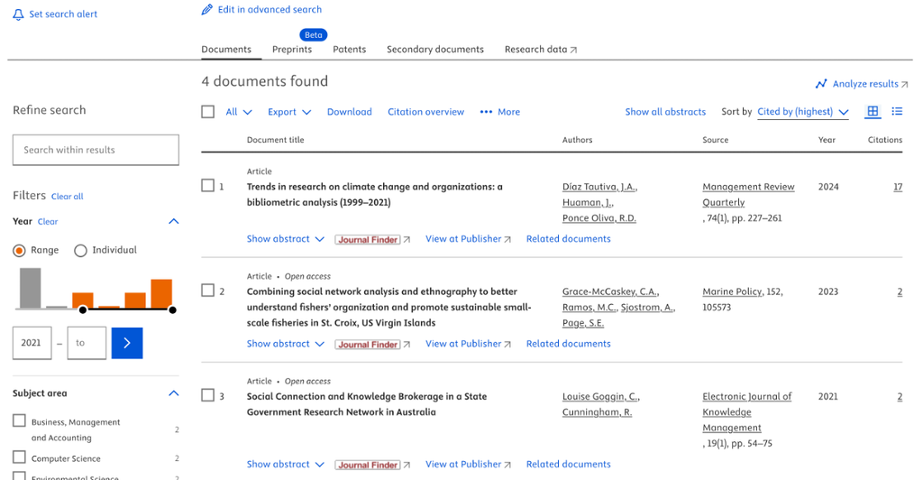

## 4.2 Reference Manager

If you haven’t done so, I strongly suggest you start using a reference manager such as Zotero or Mendeley.

These are free and you can connect them to Chrome to include your references automatically

[figure not shown]

And you can also add a plugin to Word so that you can also add the citations to your document automatically.

Check out this video 🎥 Referencing in Microsoft Word with Mendeley Reference Manager